# What Academic Studio is

## A workspace with an assistant built in

Academic Studio is a place to work on your project files with Claude, side by side.

- Your files are on the left, Claude is on the right
- Open a file and it opens as a tab in the right pane
- You can ask Claude to do the work, or do it yourself
- Under the hood it is VS Code — but set up to be simple, with Claude ready the moment it opens

[figure not shown]

Move through this tour with the → arrow keys, or the arrows at the bottom-right.

# Getting around

## The five areas of the screen

1. Activity Bar — icons on the far left switch what the side panel shows
2. Explorer — the files in your project folder
3. Main panel — where your files open and where Claude lives
4. Ask Claude — type your request here and press Enter
5. Status Bar — small readouts along the very bottom

[figure not shown]

## The Activity Bar

The narrow strip of icons on the far left. Each one opens a different panel.

- 📄 Explorer — your files
- 🔍 Search — find text across every file
- 🧩 Extensions — add-ons that give new abilities
- ✳︎ Claude Code — the assistant
- ⚙️ Settings (bottom) — preferences and your account

Click an icon to show its panel; click it again to hide it and give yourself more room.

## Menus and toolbars

Toolbars are the small rows of buttons at the top of the editor. When you open a file, buttons that make sense for it appear — a Run button for Python, a Preview button for Quarto.

[figure not shown]

## Arranging your editor

Files you open stack as tabs along the top of the editor — and you can arrange them to suit your work:

- Drag a tab left or right to reorder it
- Drag a tab to the edge of the editor to see two files side by side; the Split Editor button in the top-right toolbar does the same
- Drag a split tab back onto the others to merge them again

Handy for keeping a data file and a script, or a document and its preview, in view at once.

## Settings, if you ever need them

Settings is where you can change text size, word wrap, and the like. Most people rarely open it.

The quickest way is the Command Palette: press `F1` to bring up a search box that can run any command, then type “settings.”

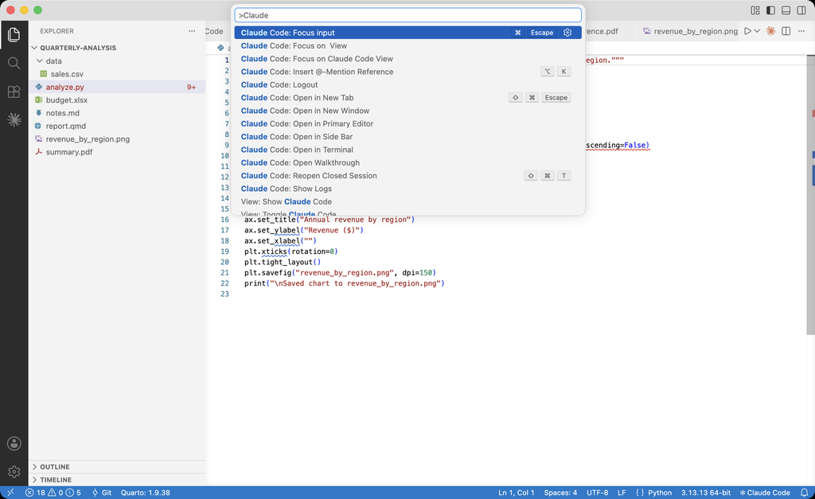

Or simplest of all, ask Claude to change a setting for you.

## The Terminal

A terminal is a place to type commands for your computer to run — installing a program or checking a result.

Open one with Terminal → New Terminal, then type the command and press Enter. Or, simplest of all, just ask Claude to run commands for you.

[figure not shown]

# Working with your files

## When you first open it

The first time you open Academic Studio you see a Start page. From here you can:

- Open Folder — choose the project you want to work on
- Run Setup — install tools and pick your profile
- Help — open the written guide

Claude opens automatically alongside it.

[figure not shown]

## Open a folder, and your files appear

Everything in Academic Studio happens inside a project folder. Choose one with File → Open Folder, and its contents show up in the Explorer.

- Click a file to open it in the editor
- Your work saves automatically
- Your Claude conversation stays with the project

[figure not shown]

## Viewing spreadsheets, PDFs, and data

You do not need Excel or a PDF reader — Academic Studio previews these files for you.

Spreadsheets, CSV data, PDFs, and Excel files all open in built-in viewers.

[figure not shown]

## The Python libraries you get

Run Setup installs Python with the libraries most academic and professional work needs:

- pandas, NumPy — data and tables
- Matplotlib, seaborn, Plotly — charts and figures
- SciPy, SymPy — scientific and symbolic math
- scikit-learn — machine learning
- statsmodels — statistics and regression
- openpyxl, python-docx, python-pptx — read and write Excel, Word, and PowerPoint

You need not memorize these — ask Claude to “analyze this spreadsheet” and it uses the right ones.

# Claude, your assistant

## Claude is ready the moment you open the app

The panel on the right is Claude Code. Type what you want in plain English and press Enter.

The fastest way to work: tell Claude what you want — “summarize this data,” “make a slide deck from these notes,” “fix this error” — and let it do the work.

[figure not shown]

A paid Anthropic account is required. The first time, type `/login` to sign in.

## Claude can read your files

Because Claude works inside your folder, it can open and read your files to answer questions — no copying and pasting.

It also works like a smart search over your documents: ask “which file mentions the 2023 budget?” and it finds the right one.

[figure not shown]

## Claude can write and edit files

Ask Claude to create or change a file and it writes it for you, right there in your folder.

By default it shows you what it plans to do and waits for your OK — so you are always in control.

[figure not shown]

## Run more than one Claude at once

You are not limited to a single conversation. Open more Claude Code sessions when you want to work on different things at the same time — one drafting a document while another analyzes data, say.

- Each session keeps its own conversation and history
- Switch between them like any other tab
- They all work in the same project folder

Start another with the new-session (+) button at the top of the Claude Code panel.

## Claude’s installed skills

A skill is a ready-made ability Claude draws on by itself. Academic Studio bundles skills for producing real documents — ask for “a budget spreadsheet” or “a ten-slide deck” and you get an actual file:

- Excel spreadsheets — `.xlsx`
- Word documents — `.docx`
- PowerPoint decks — `.pptx`
- PDF files — create, fill, and combine
- Slide decks — themed reveal.js presentations
- Skill-creator — builds new skills for repeatable tasks

You never turn these on or call them by name — Claude picks the right skill on its own.

## Skills, connectors, and plugins

Claude’s abilities can be extended in three ways:

- **Skills** teach Claude how to do specific tasks (fetching data, building documents, following a workflow)
- **Connectors** (MCP servers) give Claude access to external tools — databases, web services, APIs
- **Plugins** bundle skills and connectors into one-click installs

Browse and install:

- [Anthropic plugins directory](https://claude.com/plugins) — official plugins
- [Community plugins](https://github.com/anthropics/claude-plugins-community) — contributed by the community

## Academic Studio Packages

Academic Studio curates a small set of plugins with simplified install procedures — and some have features that work better here than on other Claude Code platforms.

- Install them from Help → Run Setup → Additional packages, checked on and added with a single click
- Run Setup handles the plugin, its skills, and any Python libraries the code needs, so everything just works
- See https://academic-studio.com for a description of each package

# Setup and help

## Run Setup: pick your profile, install the tools

Open it from Help → Run Setup. One screen lets you:

- Choose a profile (Students & Professionals, or Faculty) which turns on the right set of extensions
- Install supporting programs — Python, Node.js, Quarto — with a single click
- Install additional packages — Finance Data

[figure not shown]

You can reopen it any time to add tools or change extensions.

## Where to get help

And of course, you can always just ask Claude.

[figure not shown]

## You are ready

A few things to remember:

[figure not shown]

Welcome to Academic Studio.

When in doubt, ask Claude — tell it what you want in plain words.

For help anytime, point Claude to https://academic-studio.com.